# ICE-A: Figure 4 2

# 4 Investigation of alternative promoters for EBF1 bound T-lineage associated elements

## 4.0 Preperations

Run before: conda activate liana_analysis_env export LD_LIBRARY_PATH=$LD_LIBRARY_PATH:/opt/anaconda3/envs/liana_analysis_env/lib

Setting working directory

```r
knitr::opts_knit$set(root.dir = normalizePath("/mnt/data/common/tobias/tg/ICE_A/ICEA_analysis/"))
```

Loading packages

```r
lapply(packages, library, character.only = TRUE)
```

[output not shown]

[output not shown]

[output cut: 10 more lines]

[output not shown]

```bash
script_dir="script/figure4"
bash $script_dir/icea_consensus_230238_p2c2_atac_WT_EKO_annotate_interactions.sh
```

## 4.2 Define B/T elements

### 4.2.1 Identify B/T associated peaks

T elements: distal elements annotated to T gene list in P2C2

```r
#Load T genes
t.genes <- read.table("output/data/figure2/genelists/Tcell_genes.txt", sep = "\t")

#Load annotaiton of consensus peaks
T_elements_anno_iceaP2C2 <- read.table("output/data/figure2/annotation/atac_230238_p2c2_consensus_peaks_P2C2_H3K4me3_PLAC_annotation/Peak_annotation/atac_230238_p2c2_consensus/atac_230238_p2c2_consensus_PLACseq_annotated.txt", header=TRUE, sep="\t")
T_elements_anno_iceaP2C2$peakID <- paste0(T_elements_anno_iceaP2C2$Chr, ":", T_elements_anno_iceaP2C2$Start, "-", T_elements_anno_iceaP2C2$End)
T_elements_anno_iceaP2C2$id <- paste0(T_elements_anno_iceaP2C2$peakID, "_", T_elements_anno_iceaP2C2$Gene)
T_elements_anno_iceaP2C2_distal <- T_elements_anno_iceaP2C2[T_elements_anno_iceaP2C2$Annotation_method=="Interaction_anno" &T_elements_anno_iceaP2C2$Peak_type!="Promoter",]

#Extract T elements: Peak in P2C2 & linked to T gene
BT_elements_info <- read.table("output/data/figure2/peaks/atac_230238_p2c2_idr_consensus_info.bed", header=F, sep="\t")
colnames(BT_elements_info) <- c("chr", "start", "end", "anno")
BT_elements_info$peakID <- paste0(BT_elements_info$chr, ":", BT_elements_info$start, "-", BT_elements_info$end)

#Filter
T_elements_anno_iceaP2C2_distal <- T_elements_anno_iceaP2C2_distal[T_elements_anno_iceaP2C2_distal$Gene %in% t.genes$V1,]
T_elements_anno_iceaP2C2_distal <- T_elements_anno_iceaP2C2_distal[T_elements_anno_iceaP2C2_distal$peakID %in% BT_elements_info[BT_elements_info$anno!= "230238",]$peakID,]
T_elements_anno_iceaP2C2_distal <- T_elements_anno_iceaP2C2_distal[order(T_elements_anno_iceaP2C2_distal$Interaction_score),]
T_elements_anno_iceaP2C2_distal <- T_elements_anno_iceaP2C2_distal[!duplicated(T_elements_anno_iceaP2C2_distal$id),]

#write.table(T_elements_anno_iceaP2C2_distal[,1:3], "output/data/figure4/T_elements_anno_iceaP2C2_distal.bed", quote = F, sep = "\t", row.names = F, col.names = F)
```

B elements: distal elements annotated to B gene list in WT proB

```r
#Load T genes
b.genes <- read.table("output/data/figure2/genelists/Bcell_genes.txt", sep = "\t")

#Load annotaiton of consensus peaks
B_elements_anno_iceaWT <- read.table("output/data/figure4/annotation/Consensus_atac_WTproB_H3K4me3_PLAC_annotation/Peak_annotation/atac_230238_p2c2_consensus/atac_230238_p2c2_consensus_PLACseq_annotated.txt", header=TRUE, sep="\t")
B_elements_anno_iceaWT$peakID <- paste0(B_elements_anno_iceaWT$Chr, ":", B_elements_anno_iceaWT$Start, "-", B_elements_anno_iceaWT$End)
B_elements_anno_iceaWT$id <- paste0(B_elements_anno_iceaWT$peakID, "_", B_elements_anno_iceaWT$Gene)
B_elements_anno_iceaWT_distal <- B_elements_anno_iceaWT[B_elements_anno_iceaWT$Annotation_method=="Interaction_anno" &B_elements_anno_iceaWT$Peak_type!="Promoter",]

#Filter
B_elements_anno_iceaWT_distal <- B_elements_anno_iceaWT_distal[B_elements_anno_iceaWT_distal$Gene %in% b.genes$V1,]
B_elements_anno_iceaWT_distal <- B_elements_anno_iceaWT_distal[B_elements_anno_iceaWT_distal$peakID %in% BT_elements_info[BT_elements_info$anno!= "P2C2",]$peakID,]
B_elements_anno_iceaWT_distal <- B_elements_anno_iceaWT_distal[order(B_elements_anno_iceaWT_distal$Interaction_score),]
B_elements_anno_iceaWT_distal <- B_elements_anno_iceaWT_distal[!duplicated(B_elements_anno_iceaWT_distal$id),]

#write.table(T_elements_anno_iceaP2C2_distal[,1:3], "output/data/figure4/T_elements_anno_iceaP2C2_distal.bed", quote = F, sep = "\t", row.names = F, col.names = F)
```

### 4.2.2 B/T element association in alternative celltypes

```r
#Duw to technical issues, numer of interction vary between celltypes. Select top interactions (basde on Q-balue), matching lowser number.
int.p2c2 <-  read.table("data/interactions/P2C2_H3K4me3_FitHiChIP.interactions_FitHiC_Q0.05_MergeNearContacts.bed", header=TRUE, sep="\t")
int.wt <-  read.table("data/interactions/21_174_175_H3K4me3_FLWT_5kb_ALL2ALL.interactions_FitHiC_Q0.05_MergeNearContacts.bed", header=TRUE, sep="\t")
int.eko <-  read.table("data/interactions/13_16_176_177_H3K4me3_FLEKO_5kb_ALL2ALL.interactions_FitHiC_Q0.05_MergeNearContacts.bed", header=TRUE, sep="\t")
nint <- min(nrow(int.p2c2), nrow(int.wt), nrow(int.eko))
#nint <- 100000

int.p2c2 <- int.p2c2[order(int.p2c2$Q.Value_Bias),]
int.p2c2.top <- int.p2c2[1:nint,]
int.p2c2.cutoff <- -log10(max(int.p2c2.top$Q.Value_Bias))

int.wt <- int.wt[order(int.wt$Q.Value_Bias),]
int.wt.top <- int.wt[1:nint,]
int.wt.cutoff <- -log10(max(int.wt.top$Q.Value_Bias))

int.eko <- int.eko[order(int.eko$Q.Value_Bias),]
int.eko.top <- int.eko[1:nint,]
int.eko.cutoff <- -log10(max(int.eko.top$Q.Value_Bias))

#Load annotaiton of consensus peaks
BT_elements_anno_iceaP2C2 <- read.table("output/data/figure2/annotation/atac_230238_p2c2_consensus_peaks_P2C2_H3K4me3_PLAC_annotation/Peak_annotation/atac_230238_p2c2_consensus/atac_230238_p2c2_consensus_PLACseq_annotated.txt", header=TRUE, sep="\t")
BT_elements_anno_iceaP2C2$peakID <- paste0(BT_elements_anno_iceaP2C2$Chr, ":", BT_elements_anno_iceaP2C2$Start, "-", BT_elements_anno_iceaP2C2$End)
BT_elements_anno_iceaP2C2$id <- paste0(BT_elements_anno_iceaP2C2$peakID, "_", BT_elements_anno_iceaP2C2$Gene)
BT_elements_anno_iceaP2C2_distal <- BT_elements_anno_iceaP2C2[BT_elements_anno_iceaP2C2$Annotation_method=="Interaction_anno" &BT_elements_anno_iceaP2C2$Peak_type!="Promoter",]
BT_elements_anno_iceaP2C2_distal <- BT_elements_anno_iceaP2C2_distal[BT_elements_anno_iceaP2C2_distal$Interaction_score<max(int.p2c2.top$Q.Value_Bias),]

BT_elements_anno_iceaWT <- read.table("output/data/figure4/annotation/Consensus_atac_WTproB_H3K4me3_PLAC_annotation/Peak_annotation/atac_230238_p2c2_consensus/atac_230238_p2c2_consensus_PLACseq_annotated.txt", header=TRUE, sep="\t")
BT_elements_anno_iceaWT$peakID <- paste0(BT_elements_anno_iceaWT$Chr, ":", BT_elements_anno_iceaWT$Start, "-", BT_elements_anno_iceaWT$End)
BT_elements_anno_iceaWT$id <- paste0(BT_elements_anno_iceaWT$peakID, "_", BT_elements_anno_iceaWT$Gene)
BT_elements_anno_iceaWT_distal <- BT_elements_anno_iceaWT[BT_elements_anno_iceaWT$Annotation_method=="Interaction_anno" &BT_elements_anno_iceaWT$Peak_type!="Promoter",]
BT_elements_anno_iceaWT_distal <- BT_elements_anno_iceaWT_distal[BT_elements_anno_iceaWT_distal$Interaction_score<max(int.wt.top$Q.Value_Bias),]

BT_elements_anno_iceaEKO <- read.table("output/data/figure4/annotation/Consensus_atac_Ebf1KOproB_H3K4me3_PLAC_annotation/Peak_annotation/atac_230238_p2c2_consensus/atac_230238_p2c2_consensus_PLACseq_annotated.txt", header=TRUE, sep="\t")
BT_elements_anno_iceaEKO$peakID <- paste0(BT_elements_anno_iceaEKO$Chr, ":", BT_elements_anno_iceaEKO$Start, "-", BT_elements_anno_iceaEKO$End)
BT_elements_anno_iceaEKO$id <- paste0(BT_elements_anno_iceaEKO$peakID, "_", BT_elements_anno_iceaEKO$Gene)
BT_elements_anno_iceaEKO_distal <- BT_elements_anno_iceaEKO[BT_elements_anno_iceaEKO$Annotation_method=="Interaction_anno" &BT_elements_anno_iceaEKO$Peak_type!="Promoter",]
BT_elements_anno_iceaEKO_distal <- BT_elements_anno_iceaEKO_distal[BT_elements_anno_iceaEKO_distal$Interaction_score<max(int.eko.top$Q.Value_Bias),]
```

Merge annotation of T elements for P2C2 and WT/Ebf1KO

```r
#T elements
T.element.anno <- T_elements_anno_iceaP2C2_distal[,c(18, 17, 1:3, 6,9,5)]

T.element.anno$Tgene_p2c2 <- "tgene"
T.element.anno$Tgene_WT<- ifelse(T.element.anno$id %in% BT_elements_anno_iceaWT_distal$id, "tgene", "NA")
T.element.anno$Tgene_EKO<- ifelse(T.element.anno$id %in% BT_elements_anno_iceaEKO_distal$id, "tgene", "NA")

#B elements
B.element.anno <- B_elements_anno_iceaWT_distal[,c(18, 17, 1:3, 6,9,5)]

B.element.anno$Bgene_WT <- "bgene"
B.element.anno$Bgene_EKO<- ifelse(B.element.anno$id %in% BT_elements_anno_iceaEKO_distal$id, "bgene", "NA")
B.element.anno$Bgene_p2c2 <- ifelse(B.element.anno$id %in% BT_elements_anno_iceaP2C2_distal$id, "bgene", "NA")
```

## 4.3 Alternative tss

### 4.3.1 Define promoters & pseudopromoters

For annotation to pseudopromters, custom tss locations are required. All potential promoters/pseudopromoters regions defines as ATAC-seq peaks overlapping H3K4me3 in other celltype

```bash
bash script/general/bedtools_intersect_wa.sh data/atac/peaks/ATAC_FLproB_WT_idr_optimal_peak.narrowPeak data/chip_cnr/peaks/H3K4me3_WT_optimal_set.IDR0.05.narrowPeak output/data/figure4/elements/WT_atac_H3K4me3_overlap.bed

bash script/general/bedtools_intersect_wa.sh data/atac/peaks/p2c2_atac_idr.optimal_peak.narrowPeak data/chip_cnr/peaks/CnR_P2C2_H3K4me3_consensus_peaks.bed output/data/figure4/elements/P2C2_atac_H3K4me3_overlap.bed
```

Organize defined promoters regions to be compatible with custom TSS input in ICE_A

```r
#B
#Load custom promoter regions
custom.promoters.B <- read.table("output/data/figure4/elements/WT_atac_H3K4me3_overlap.bed", header=F, sep="\t", quote = "")
custom.promoters.B <- custom.promoters.B[,1:3]
colnames(custom.promoters.B) <- c("chr", "start", "end")
custom.promoters.B$peakID <- paste0(custom.promoters.B$chr, ":",custom.promoters.B$start, "-", custom.promoters.B$end)
custom.promoters.B <- custom.promoters.B[!duplicated(custom.promoters.B),]

#Writing custom tss.txt file for ICE-A annotation
custom.promoters.B <- custom.promoters.B[,c(4,1:3)]
custom.promoters.B$strand=0
write.table(custom.promoters.B, "output/data/figure4/annotation/custom_tss_B.txt", quote = F, sep = "\t", row.names = F, col.names = F)


#T
custom.promoters.T <- read.table("output/data/figure4/elements/P2C2_atac_H3K4me3_overlap.bed", header=F, sep="\t", quote = "")
custom.promoters.T <- custom.promoters.T[,1:3]
colnames(custom.promoters.T) <- c("chr", "start", "end")
custom.promoters.T$peakID <- paste0(custom.promoters.T$chr, ":",custom.promoters.T$start, "-", custom.promoters.T$end)
custom.promoters.T <- custom.promoters.T[!duplicated(custom.promoters.T),]

#Writing custom tss.txt file for ICE-A annotation
custom.promoters.T <- custom.promoters.T[,c(4,1:3)]
custom.promoters.T$strand=0
write.table(custom.promoters.T, "output/data/figure4/annotation/custom_tss_T.txt", quote = F, sep = "\t", row.names = F, col.names = F)
```

### 4.3.2 Custom annotation with defined alternative promoters

```bash
script_dir="script/figure4"
bash $script_dir/icea_consensus_atac_P2C2_WT_EKO_custom_tss_2.sh
```

[output not shown]

[output cut: 155 more lines]

[output not shown]

### 4.3.3 Alternative annotation

```r
#T elements
#Load annotaiton of consensus peaks
tss_anno_iceaP2C2_T <- read.table("output/data/figure4/annotation/Consensus_atac_P2C2_H3K4me3_PLAC_annotation_custom_TSS_B/Peak_annotation/atac_230238_p2c2_consensus/atac_230238_p2c2_consensus_PLACseq_annotated.txt", header=TRUE, sep="\t")
tss_anno_iceaP2C2_T$peakID <- paste0(tss_anno_iceaP2C2_T$Chr, ":", tss_anno_iceaP2C2_T$Start, "-", tss_anno_iceaP2C2_T$End)
tss_anno_iceaP2C2_T$id <- paste0(tss_anno_iceaP2C2_T$peakID, "_", tss_anno_iceaP2C2_T$Gene)
tss_anno_iceaP2C2_T_distal <- tss_anno_iceaP2C2_T[tss_anno_iceaP2C2_T$Annotation_method=="Interaction_anno" &tss_anno_iceaP2C2_T$Peak_type!="Promoter",]
tss_anno_iceaP2C2_T_distal <- tss_anno_iceaP2C2_T_distal[tss_anno_iceaP2C2_T_distal$Interaction_score<max(int.p2c2.top$Q.Value_Bias),]

tss_anno_iceaWT_T <- read.table("output/data/figure4/annotation/Consensus_atac_WTproB_H3K4me3_PLAC_annotation_custom_TSS_B//Peak_annotation/atac_230238_p2c2_consensus/atac_230238_p2c2_consensus_PLACseq_annotated.txt", header=TRUE, sep="\t")
tss_anno_iceaWT_T$peakID <- paste0(tss_anno_iceaWT_T$Chr, ":", tss_anno_iceaWT_T$Start, "-", tss_anno_iceaWT_T$End)
tss_anno_iceaWT_T$id <- paste0(tss_anno_iceaWT_T$peakID, "_", tss_anno_iceaWT_T$Gene)
tss_anno_iceaWT_T_distal <- tss_anno_iceaWT_T[tss_anno_iceaWT_T$Annotation_method=="Interaction_anno" &tss_anno_iceaWT_T$Peak_type!="Promoter",]
tss_anno_iceaWT_T_distal <- tss_anno_iceaWT_T_distal[tss_anno_iceaWT_T_distal$Interaction_score<max(int.wt.top$Q.Value_Bias),]

tss_anno_iceaEKO_T <- read.table("output/data/figure4/annotation/Consensus_atac_Ebf1KOproB_H3K4me3_PLAC_annotation_custom_TSS_B/Peak_annotation/atac_230238_p2c2_consensus/atac_230238_p2c2_consensus_PLACseq_annotated.txt", header=TRUE, sep="\t")
tss_anno_iceaEKO_T$peakID <- paste0(tss_anno_iceaEKO_T$Chr, ":", tss_anno_iceaEKO_T$Start, "-", tss_anno_iceaEKO_T$End)
tss_anno_iceaEKO_T$id <- paste0(tss_anno_iceaEKO_T$peakID, "_", tss_anno_iceaEKO_T$Gene)
tss_anno_iceaEKO_T_distal <- tss_anno_iceaEKO_T[tss_anno_iceaEKO_T$Annotation_method=="Interaction_anno" &tss_anno_iceaEKO_T$Peak_type!="Promoter",]
tss_anno_iceaEKO_T_distal <- tss_anno_iceaEKO_T_distal[tss_anno_iceaEKO_T_distal$Interaction_score<max(int.eko.top$Q.Value_Bias),]


#B elements
#Load annotaiton of consensus peaks
tss_anno_iceaP2C2_B <- read.table("output/data/figure4/annotation/Consensus_atac_P2C2_H3K4me3_PLAC_annotation_custom_TSS_T/Peak_annotation/atac_230238_p2c2_consensus/atac_230238_p2c2_consensus_PLACseq_annotated.txt", header=TRUE, sep="\t")
tss_anno_iceaP2C2_B$peakID <- paste0(tss_anno_iceaP2C2_B$Chr, ":", tss_anno_iceaP2C2_B$Start, "-", tss_anno_iceaP2C2_B$End)
tss_anno_iceaP2C2_B$id <- paste0(tss_anno_iceaP2C2_B$peakID, "_", tss_anno_iceaP2C2_B$Gene)
tss_anno_iceaP2C2_B_distal <- tss_anno_iceaP2C2_B[tss_anno_iceaP2C2_B$Annotation_method=="Interaction_anno" &tss_anno_iceaP2C2_B$Peak_type!="Promoter",]
tss_anno_iceaP2C2_B_distal <- tss_anno_iceaP2C2_B_distal[tss_anno_iceaP2C2_B_distal$Interaction_score<max(int.p2c2.top$Q.Value_Bias),]

tss_anno_iceaWT_B <- read.table("output/data/figure4/annotation/Consensus_atac_WTproB_H3K4me3_PLAC_annotation_custom_TSS_T/Peak_annotation/atac_230238_p2c2_consensus/atac_230238_p2c2_consensus_PLACseq_annotated.txt", header=TRUE, sep="\t")
tss_anno_iceaWT_B$peakID <- paste0(tss_anno_iceaWT_B$Chr, ":", tss_anno_iceaWT_B$Start, "-", tss_anno_iceaWT_B$End)
tss_anno_iceaWT_B$id <- paste0(tss_anno_iceaWT_B$peakID, "_", tss_anno_iceaWT_B$Gene)
tss_anno_iceaWT_B_distal <- tss_anno_iceaWT_B[tss_anno_iceaWT_B$Annotation_method=="Interaction_anno" &tss_anno_iceaWT_B$Peak_type!="Promoter",]
tss_anno_iceaWT_B_distal <- tss_anno_iceaWT_B_distal[tss_anno_iceaWT_B_distal$Interaction_score<max(int.wt.top$Q.Value_Bias),]

tss_anno_iceaEKO_B <- read.table("output/data/figure4/annotation/Consensus_atac_Ebf1KOproB_H3K4me3_PLAC_annotation_custom_TSS_T/Peak_annotation/atac_230238_p2c2_consensus/atac_230238_p2c2_consensus_PLACseq_annotated.txt", header=TRUE, sep="\t")
tss_anno_iceaEKO_B$peakID <- paste0(tss_anno_iceaEKO_B$Chr, ":", tss_anno_iceaEKO_B$Start, "-", tss_anno_iceaEKO_B$End)
tss_anno_iceaEKO_B$id <- paste0(tss_anno_iceaEKO_B$peakID, "_", tss_anno_iceaEKO_B$Gene)
tss_anno_iceaEKO_B_distal <- tss_anno_iceaEKO_B[tss_anno_iceaEKO_B$Annotation_method=="Interaction_anno" &tss_anno_iceaEKO_B$Peak_type!="Promoter",]
tss_anno_iceaEKO_B_distal <- tss_anno_iceaEKO_B_distal[tss_anno_iceaEKO_B_distal$Interaction_score<max(int.eko.top$Q.Value_Bias),]
```

Annotate custom TSS (to define real/pseudo-promoters)

```bash
cd output/data/figure4/annotation

#Alt prom in B
cut -f2-4 custom_tss_B.txt > custom_tss_B.bed
annotatePeaks.pl custom_tss_B.bed mm10 > custom_tss_B_homer_annotation.txt
awk -v FS='\t' -v OFS='\t' '{print $2, $3, $4, $16, $10}' custom_tss_B_homer_annotation.txt > custom_tss_B_homer_annotation_cut.txt

#Alt prom in T
cut -f2-4 custom_tss_T.txt > custom_tss_T.bed
annotatePeaks.pl custom_tss_T.bed mm10 > custom_tss_T_homer_annotation.txt
awk -v FS='\t' -v OFS='\t' '{print $2, $3, $4, $16, $10}' custom_tss_T_homer_annotation.txt > custom_tss_T_homer_annotation_cut.txt
```

[output not shown]

[output cut: 103 more lines]

[output not shown]

```r
#Atl in B
custom_tss_anno_B <- read.table("output/data/figure4/annotation/custom_tss_B_homer_annotation_cut.txt", header=T, sep="\t")
custom_tss_anno_B$Start <- custom_tss_anno_B$Start-1
custom_tss_anno_B$peakID <- paste0(custom_tss_anno_B$Chr, ":", custom_tss_anno_B$Start, "-", custom_tss_anno_B$End)
custom_tss_anno_B$promoter <- ifelse(abs(custom_tss_anno_B$Distance.to.TSS)<= 1000,1,0)
write.table(custom_tss_anno_B[custom_tss_anno_B$promoter==1,1:3], "output/data/figure4/annotation/custom_tss_promoters_B.bed", quote = F, sep = "\t", row.names = F, col.names = F)
write.table(custom_tss_anno_B[custom_tss_anno_B$promoter==0,1:3], "output/data/figure4/annotation/custom_tss_pseudopromoters_B.bed", quote = F, sep = "\t", row.names = F, col.names = F)

#Atl in T
custom_tss_anno_T <- read.table("output/data/figure4/annotation/custom_tss_T_homer_annotation_cut.txt", header=T, sep="\t")
custom_tss_anno_T$Start <- custom_tss_anno_T$Start-1
custom_tss_anno_T$peakID <- paste0(custom_tss_anno_T$Chr, ":", custom_tss_anno_T$Start, "-", custom_tss_anno_T$End)
custom_tss_anno_T$promoter <- ifelse(abs(custom_tss_anno_T$Distance.to.TSS)<= 1000,1,0)
write.table(custom_tss_anno_T[custom_tss_anno_T$promoter==1,1:3], "output/data/figure4/annotation/custom_tss_promoters_T.bed", quote = F, sep = "\t", row.names = F, col.names = F)
write.table(custom_tss_anno_T[custom_tss_anno_T$promoter==0,1:3], "output/data/figure4/annotation/custom_tss_pseudopromoters_T.bed", quote = F, sep = "\t", row.names = F, col.names = F)
```

### 4.3.4 Overlap with EBF1 biding in alternative TSS

```bash
#ALt in B
bash script/general/bedtools_intersect_wa.sh output/data/figure4/annotation/custom_tss_B.bed data/chip_cnr/peaks/GSE159957_230_238_a_Ebf1_IDR-peaks.bed output/data/figure4/annotation/custom_tss_Ebf1_overlap_B.bed

#Alt in T
bash script/general/bedtools_intersect_wa.sh output/data/figure4/annotation/custom_tss_T.bed data/chip_cnr/peaks/GSE159957_230_238_a_Ebf1_IDR-peaks.bed output/data/figure4/annotation/custom_tss_Ebf1_overlap_T.bed
```

```r
#Alt in B
custom_tss_ebf1_B <- read.table("output/data/figure4/annotation/custom_tss_Ebf1_overlap_B.bed", header=F, sep="\t")
colnames(custom_tss_ebf1_B) <- c("chr", "start", "end")
custom_tss_ebf1_B$peakID <- paste0(custom_tss_ebf1_B$chr, ":", custom_tss_ebf1_B$start, "-", custom_tss_ebf1_B$end)

#ALt inT
custom_tss_ebf1_T <- read.table("output/data/figure4/annotation/custom_tss_Ebf1_overlap_T.bed", header=F, sep="\t")
colnames(custom_tss_ebf1_T) <- c("chr", "start", "end")
custom_tss_ebf1_T$peakID <- paste0(custom_tss_ebf1_T$chr, ":", custom_tss_ebf1_T$start, "-", custom_tss_ebf1_T$end)
```

### 4.3.5 Combine

```r
#T elements
# Alterantive tss (based on WT annotation)
tss.alt.T <- tss_anno_iceaWT_T_distal[,c(18,17,1:3, 9,5, 14)]
tss.alt.T <- tss.alt.T[tss.alt.T$peakID %in% T.element.anno$peakID,]
tss.alt.T <- tss.alt.T[order(tss.alt.T$Interaction_score),]
tss.alt.T <- tss.alt.T[!duplicated(tss.alt.T),]

#Add info about real/pseudo-promoter
T.element.anno <- merge(T.element.anno, tss.alt.T[,c(2,1,3:5,6, 7)], by="peakID", all.x=T)
T.element.anno$promoter <- ifelse(T.element.anno$Gene.y %in% custom_tss_anno_B[custom_tss_anno_B$promoter==1,]$peakID, "Promoter",ifelse(T.element.anno$Gene.y %in% custom_tss_anno_B[custom_tss_anno_B$promoter==0,]$peakID, "Pseudo","NA"))
T.element.anno$ebf1 <- ifelse(T.element.anno$Gene.y %in% custom_tss_ebf1_B$peakID, "Ebf1","NA")

#Add info about interaction in cell types
T.element.anno$tss_p2c2 <- ifelse(T.element.anno$id.y %in% tss_anno_iceaP2C2_T_distal$id, "alt", "NA")
T.element.anno$tss_WT<- ifelse(T.element.anno$id.y %in% tss_anno_iceaWT_T_distal$id, "alt", "NA")
T.element.anno$tss_EKO <- ifelse(T.element.anno$id.y %in% tss_anno_iceaEKO_T_distal$id,"alt", "NA")

#Save for supplementary
T.element.anno.supp <- T.element.anno[,c(1,3:8,9,10:11,16:22)]
T.element.anno.supp$Tgene_P2C2 <- ifelse(T.element.anno.supp$Tgene_p2c2=="tgene", 1,0)
T.element.anno.supp$Tgene_WT <- ifelse(T.element.anno.supp$Tgene_WT=="tgene", 1,0)
T.element.anno.supp$Tgene_EKO <- ifelse(T.element.anno.supp$Tgene_EKO=="tgene", 1,0)
T.element.anno.supp$tss_p2c2 <- ifelse(T.element.anno.supp$tss_p2c2=="alt", 1,0)
T.element.anno.supp$tss_WT <- ifelse(T.element.anno.supp$tss_WT=="alt", 1,0)
T.element.anno.supp$tss_EKO <- ifelse(T.element.anno.supp$tss_EKO=="alt", 1,0)
T.element.anno.supp$ebf1 <- ifelse(T.element.anno.supp$ebf1=="Ebf1", 1,0)
colnames(T.element.anno.supp) <- c("peakID", "Chr", "Start", "End", "EntrezID", "Tgene", "Distance_to_Tgene", "Tgene_in_WT", "Tgene_in_Ebf1KO", "Alternative_promoter", "Distance_to_alt_promoter", "Alt_promoter_type", "Ebf1_occupancy", "Alt_promoter_in_P2C2", "Alt_promoter_in_WT","Alt_promoter_in_Ebf1KO")
#write.table(T.element.anno.supp, file = "output/data/figure4/Supp_table_1G_alternative_promoters_Tgenes.txt", quote = FALSE, sep = "\t", row.names = FALSE, col.names = T)



#B elements
# Alterantive tss (based on WT annotation)
tss.alt.B <- tss_anno_iceaP2C2_B_distal[,c(18,17,1:3, 9,5, 14)]
tss.alt.B <- tss.alt.B[tss.alt.B$peakID %in% B.element.anno$peakID,]
tss.alt.B <- tss.alt.B[order(tss.alt.B$Interaction_score),]
tss.alt.B <- tss.alt.B[!duplicated(tss.alt.B),]

#Add info about real/pseudo-promoter
B.element.anno <- merge(B.element.anno, tss.alt.B[,c(2,1,3:5,6, 7)], by="peakID", all.x=T)
B.element.anno$promoter <- ifelse(B.element.anno$Gene.y %in% custom_tss_anno_T[custom_tss_anno_T$promoter==1,]$peakID, "Promoter",ifelse(B.element.anno$Gene.y %in% custom_tss_anno_T[custom_tss_anno_T$promoter==0,]$peakID, "Pseudo","NA"))
B.element.anno$ebf1 <- ifelse(B.element.anno$Gene.y %in% custom_tss_ebf1_T$peakID, "Ebf1","NA")

#Add info about interaction in cell types
B.element.anno$tss_p2c2 <- ifelse(B.element.anno$id.y %in% tss_anno_iceaP2C2_B_distal$id, "alt", "NA")
B.element.anno$tss_WT<- ifelse(B.element.anno$id.y %in% tss_anno_iceaWT_B_distal$id, "alt", "NA")
B.element.anno$tss_EKO <- ifelse(B.element.anno$id.y %in% tss_anno_iceaEKO_B_distal$id,"alt", "NA")

#Save for supplementary
B.element.anno.supp <- B.element.anno[,c(1,3:8,9,10:11,16:22)]
B.element.anno.supp$Bgene_P2C2 <- ifelse(B.element.anno.supp$Bgene_p2c2=="bgene", 1,0)
B.element.anno.supp$Bgene_WT <- ifelse(B.element.anno.supp$Bgene_WT=="bgene", 1,0)
B.element.anno.supp$Bgene_EKO <- ifelse(B.element.anno.supp$Bgene_EKO=="bgene", 1,0)
B.element.anno.supp$tss_p2c2 <- ifelse(B.element.anno.supp$tss_p2c2=="alt", 1,0)
B.element.anno.supp$tss_WT <- ifelse(B.element.anno.supp$tss_WT=="alt", 1,0)
B.element.anno.supp$tss_EKO <- ifelse(B.element.anno.supp$tss_EKO=="alt", 1,0)
B.element.anno.supp$ebf1 <- ifelse(B.element.anno.supp$ebf1=="Ebf1", 1,0)
colnames(B.element.anno.supp) <- c("peakID", "Chr", "Start", "End", "EntrezID", "Tgene", "Distance_to_Tgene", "Tgene_in_WT", "Tgene_in_Ebf1KO", "Alternative_promoter", "Distance_to_alt_promoter", "Alt_promoter_type", "Ebf1_occupancy", "Alt_promoter_in_P2C2", "Alt_promoter_in_WT","Alt_promoter_in_Ebf1KO")
#write.table(T.element.anno.supp, file = "output/data/figure4/Supp_table_1G_alternative_promoters_Tgenes.txt", quote = FALSE, sep = "\t", row.names = FALSE, col.names = T)
```

### 4.4.1 Filter and organize input

Order

```r
#T
T.element.anno.sort <- T.element.anno
T.element.anno.sort$Chr.x <- factor(gsub("chr","",T.element.anno.sort$Chr.x), levels = c(1:19, "X", "Y"))
T.element.anno.sort$Chr.y <- factor(gsub("chr","",T.element.anno.sort$Chr.y), levels = c(1:19, "X", "Y"))
T.element.anno.sort <- T.element.anno.sort[order(T.element.anno.sort$Chr.y, T.element.anno.sort$Start.y),]

#B
B.element.anno.sort <- B.element.anno
B.element.anno.sort$Chr.x <- factor(gsub("chr","",B.element.anno.sort$Chr.x), levels = c(1:19, "X", "Y"))
B.element.anno.sort$Chr.y <- factor(gsub("chr","",B.element.anno.sort$Chr.y), levels = c(1:19, "X", "Y"))
B.element.anno.sort <- B.element.anno.sort[order(B.element.anno.sort$Chr.y, B.element.anno.sort$Start.y),]
```

```r
length(links.p2c2.T[links.p2c2.T$section=="T_promoter",]$from)#/length(unique(links.p2c2$from))*100
```

```
[1] 492
```

```r
length(links.WT.T[links.WT.T$section=="T_promoter",]$from)#/length(unique(links.p2c2$from))*100
```

```
[1] 194
```

```r
length(links.EKO.T[links.EKO.T$section=="T_promoter",]$from)#/length(unique(links.p2c2$from))*100
```

```
[1] 360
```

```r
length(links.p2c2.T[links.p2c2.T$section=="Alt_promoter",]$from)#/length(unique(links.p2c2$from))*100
```

```
[1] 151
```

```r
length(links.WT.T[links.WT.T$section=="Alt_promoter",]$from)#/length(unique(links.p2c2$from))*100
```

```
[1] 270
```

```r
length(links.EKO.T[links.EKO.T$section=="Alt_promoter",]$from)#/length(unique(links.p2c2$from))*100
```

```
[1] 230
```

```r
length(links.p2c2.T[links.p2c2.T$section=="Alt_pseudo",]$from)#/length(unique(links.p2c2$from))*100
```

```
[1] 31
```

```r
length(links.WT.T[links.WT.T$section=="Alt_pseudo",]$from)#/length(unique(links.p2c2$from))*100
```

```
[1] 66
```

```r
length(links.EKO.T[links.EKO.T$section=="Alt_pseudo",]$from)#/length(unique(links.p2c2$from))*100
```

```
[1] 42
```

Plot -B OBS: During emrge make sure, interaktions between pseduo/prom are removed (when B element is also T pseudo)

```r
length(links.p2c2.B[links.p2c2.B$section=="B_promoter",]$from)#/length(unique(links.p2c2$from))*100
```

```
[1] 458
```

```r
length(links.WT.B[links.WT.B$section=="B_promoter",]$from)#/length(unique(links.p2c2$from))*100
```

```
[1] 2665
```

```r
length(links.EKO.B[links.EKO.B$section=="B_promoter",]$from)#/length(unique(links.p2c2$from))*100
```

```
[1] 1859
```

```r
length(links.p2c2.B[links.p2c2.B$section=="Alt_promoter",]$from)#/length(unique(links.p2c2$from))*100
```

```
[1] 1117
```

```r
length(links.WT.B[links.WT.B$section=="Alt_promoter",]$from)#/length(unique(links.p2c2$from))*100
```

```
[1] 843
```

```r
length(links.EKO.B[links.EKO.B$section=="Alt_promoter",]$from)#/length(unique(links.p2c2$from))*100
```

```
[1] 939
```

```r
length(links.p2c2.B[links.p2c2.B$section=="Alt_pseudo",]$from)#/length(unique(links.p2c2$from))*100
```

```
[1] 85
```

```r
length(links.WT.B[links.WT.B$section=="Alt_pseudo",]$from)#/length(unique(links.p2c2$from))*100
```

```
[1] 65
```

```r
length(links.EKO.B[links.EKO.B$section=="Alt_pseudo",]$from)#/length(unique(links.p2c2$from))*100
```

```
[1] 63
```

## 4.5 Changes in gene expression at B/T genes in EKOvsWT

### 4.5.1 Load and organize RNA-seq data from WT/EBf1KO

```r
rna.norm.WT.EKO <- read.table("data/rna/GSE92434_Analyze-repeats-FL-ProB-WT-EKO-PKO-mm10-count-exons-Condense-genes-with-adjust.txt", header = T, sep = "\t", quote = "", fill = T)
rna.norm.WT.EKO <- rna.norm.WT.EKO[,c(1,9:14)]
colnames(rna.norm.WT.EKO) <- c("refseq", "WT_1", "WT_2", "WT_3", "EKO_1", "EKO_2", "EKO_3")
rna.norm.WT.EKO$entrezID <- mapIds(org.Mm.eg.db, keys=rna.norm.WT.EKO$refseq, column="ENTREZID", keytype="REFSEQ")
rna.norm.WT.EKO$symbol <- mapIds(org.Mm.eg.db, keys=rna.norm.WT.EKO$refseq, column="SYMBOL", keytype="REFSEQ")
rna.norm.WT.EKO <- rna.norm.WT.EKO[!is.na(rna.norm.WT.EKO$entrezID),]
rna.norm.WT.EKO <- rna.norm.WT.EKO[,c(1,8,9,2:7)]

#Calculate mean and log2FC
rna.norm.WT.EKO$WT_mean <- rowMeans(rna.norm.WT.EKO[,4:6])
rna.norm.WT.EKO$EKO_mean <- rowMeans(rna.norm.WT.EKO[,7:9])
rna.norm.WT.EKO$log2FC <- log2((rna.norm.WT.EKO$WT_mean+0.1)/(rna.norm.WT.EKO$EKO_mean+0.1))
```

### 4.5.2 Merge with interaction data

```r
T.int.ebf1 <- T.int.ebf1[,c(1,12,13,14,15,16)]
```

[output not shown]

### 4.5.3 Viloin plot

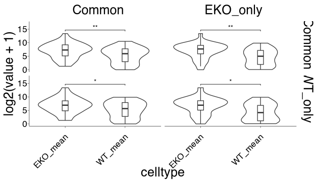

## 4.6 Generate tracks files for T element interactions

### 4.6.1 Filter interaction

```r
#Use all interaction for P2C2 and use top 100k interactions for WT/EKO. Filter for interactions with T element in any of the anchor points

#P2C2
#Load annotated interaction and filter for T element in any anhor point
int.p2c2.anno <- read.table("output/data/figure2/annotation/atac_230238_p2c2_consensus_peaks_P2C2_H3K4me3_PLAC_annotation/Interaction_annotation/Peak_sepcific_interactions/atac_230238_p2c2_consensus_PLACseq_interactions.txt", header=TRUE, sep="\t")
int.p2c2.anno <- int.p2c2.anno %>% separate_rows(Peak1_ID, sep = ",")  %>% separate_rows(Peak2_ID, sep = ",")
int.p2c2.anno.T <- int.p2c2.anno[int.p2c2.anno$Peak1_ID %in% T_elements_anno_iceaP2C2_distal$peakID | int.p2c2.anno$Peak2_ID %in% T_elements_anno_iceaP2C2_distal$peakID,]

#Prepare long-format
int.p2c2.longrange <- rbind(data.frame(chr=int.p2c2.anno.T$chr1, start=int.p2c2.anno.T$s1, end=int.p2c2.anno.T$e1, loc2=paste0(int.p2c2.anno.T$chr2, ":", int.p2c2.anno.T$s2, "-", int.p2c2.anno.T$e2, ",", -log10(int.p2c2.anno.T$Interaction_score))),data.frame(chr=int.p2c2.anno.T$chr2, start=int.p2c2.anno.T$s2, end=int.p2c2.anno.T$e2, loc2=paste0(int.p2c2.anno.T$chr1, ":", int.p2c2.anno.T$s1, "-", int.p2c2.anno.T$e1, ",", -log10(int.p2c2.anno.T$Interaction_score))))
int.p2c2.longrange <- int.p2c2.longrange[!duplicated(int.p2c2.longrange),]
write.table(int.p2c2.longrange, file = "output/data/figure4/interactions/Telement_interactions_p2c2.bed", quote = FALSE, sep = "\t", row.names = FALSE, col.names = FALSE)


#WT
#Load annotated interaction and filter for T element in any anhor point
int.wt.anno <- read.table("output/data/figure4/annotation/Consensus_atac_WTproB_H3K4me3_PLAC_annotation/Interaction_annotation/Peak_sepcific_interactions/atac_230238_p2c2_consensus_PLACseq_interactions.txt", header=TRUE, sep="\t")
int.wt.anno <- int.wt.anno %>% separate_rows(Peak1_ID, sep = ",")  %>% separate_rows(Peak2_ID, sep = ",")
int.wt.anno.T <- int.wt.anno[int.wt.anno$Peak1_ID %in% T_elements_anno_iceaP2C2_distal$peakID | int.wt.anno$Peak2_ID %in% T_elements_anno_iceaP2C2_distal$peakID,]
int.wt.anno.T <- int.wt.anno.T[int.wt.anno.T$Interaction_score <= 10^-(int.wt.cutoff),]

#Prepare long-format
int.wt.longrange <- rbind(data.frame(chr=int.wt.anno.T$chr1, start=int.wt.anno.T$s1, end=int.wt.anno.T$e1, loc2=paste0(int.wt.anno.T$chr2, ":", int.wt.anno.T$s2, "-", int.wt.anno.T$e2, ",", -log10(int.wt.anno.T$Interaction_score))),data.frame(chr=int.wt.anno.T$chr2, start=int.wt.anno.T$s2, end=int.wt.anno.T$e2, loc2=paste0(int.wt.anno.T$chr1, ":", int.wt.anno.T$s1, "-", int.wt.anno.T$e1, ",", -log10(int.wt.anno.T$Interaction_score))))
int.wt.longrange <- int.wt.longrange[!duplicated(int.wt.longrange),]
write.table(int.wt.longrange, file = "output/data/figure4/interactions/Telement_interactions_WT.bed", quote = FALSE, sep = "\t", row.names = FALSE, col.names = FALSE)

#EKO
#Load annotated interaction and filter for T element in any anhor point
int.eko.anno <- read.table("output/data/figure4/annotation/Consensus_atac_Ebf1KOproB_H3K4me3_PLAC_annotation/Interaction_annotation/Peak_sepcific_interactions/atac_230238_p2c2_consensus_PLACseq_interactions.txt", header=TRUE, sep="\t")
int.eko.anno <- int.eko.anno %>% separate_rows(Peak1_ID, sep = ",")  %>% separate_rows(Peak2_ID, sep = ",")
int.eko.anno.T <- int.eko.anno[int.eko.anno$Peak1_ID %in% T_elements_anno_iceaP2C2_distal$peakID | int.eko.anno$Peak2_ID %in% T_elements_anno_iceaP2C2_distal$peakID,]

#Prepare long-format
int.eko.longrange <- rbind(data.frame(chr=int.eko.anno.T$chr1, start=int.eko.anno.T$s1, end=int.eko.anno.T$e1, loc2=paste0(int.eko.anno.T$chr2, ":", int.eko.anno.T$s2, "-", int.eko.anno.T$e2, ",", -log10(int.eko.anno.T$Interaction_score))),data.frame(chr=int.eko.anno.T$chr2, start=int.eko.anno.T$s2, end=int.eko.anno.T$e2, loc2=paste0(int.eko.anno.T$chr1, ":", int.eko.anno.T$s1, "-", int.eko.anno.T$e1, ",", -log10(int.eko.anno.T$Interaction_score))))
int.eko.longrange <- int.eko.longrange[!duplicated(int.eko.longrange),]
write.table(int.eko.longrange, file = "output/data/figure4/interactions/Telement_interactions_EKO.bed", quote = FALSE, sep = "\t", row.names = FALSE, col.names = FALSE)
```

### 4.6.2 Prepare tracks for washU

```bash
cd output/data/figure4/interactions/

#p2c2
sort -k1,1 -k2,2n Telement_interactions_p2c2.bed > Telement_interactions_p2c2_s.bed
bgzip Telement_interactions_p2c2_s.bed
tabix -p bed Telement_interactions_p2c2_s.bed.gz

#eko
sort -k1,1 -k2,2n Telement_interactions_EKO.bed > Telement_interactions_EKO_s.bed
bgzip Telement_interactions_EKO_s.bed
tabix -p bed Telement_interactions_EKO_s.bed.gz

#wt
sort -k1,1 -k2,2n Telement_interactions_WT.bed > Telement_interactions_WT_s.bed
bgzip Telement_interactions_WT_s.bed
tabix -p bed Telement_interactions_WT_s.bed.gz

#promoters & pseudopromoters
sort -k1,1 -k2,2n ../annotation/custom_tss_promoters.bed > custom_tss_promoters_s.bed
bgzip custom_tss_promoters_s.bed
tabix -p bed custom_tss_promoters_s.bed.gz

sort -k1,1 -k2,2n ../annotation/custom_tss_pseudopromoters.bed > custom_tss_pseudopromoters_s.bed
bgzip custom_tss_pseudopromoters_s.bed
tabix -p bed custom_tss_pseudopromoters_s.bed.gz

#telements
sort -k1,1 -k2,2n ../T_elements_anno_iceaP2C2_distal.bed > T_elements_anno_iceaP2C2_distal_s.bed
bgzip T_elements_anno_iceaP2C2_distal_s.bed
tabix -p bed T_elements_anno_iceaP2C2_distal_s.bed.gz
```